# Maria Deka PD3

maria deka

2023-03-28

## 1. Wprowadzenie

W ramach pracy domowej 3 przeprowadziłam eksperyment sprawdzający działanie dobrych praktyk w wizualizacji danych. W swoim eksperymencie skupiłam się na różnicy między wykresami o współrzędnych biegunowych i kartezjańskich. Przypuszczam, że bardziej czytelne będą wykresy, w których zostały wykorzystane współrzędne kartezjańskie, od wykresów ze współrzędnymi biegunowymi.

## 2. Opis eksperymentu

Następnie za pomocą formularza Google Forms stworzyłam ankietę, w której umieściłam po jednym pytaniu, do każdego z wykresów. Zadaniem ankietowanych było odczytanie z nich danych i wybór poprawnej odpowiedzi. W ankiecie wzięło udział 21 osób w wieku od 17 do 23 lat.

## 3. Odpowiedzi ankietowanych

### Wykres 1

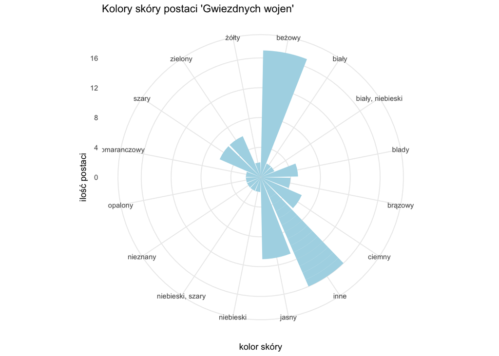

Pytanie sprawdzające umiejętność odczytania danych z powyższego wykresu brzmiało następująco:

“Ile postaci z”Gwiezdnych Wojen” ma skórę koloru zielonego?“, do wyboru były trzy odpowiedzi:

1. 6
2. 4
3. 8

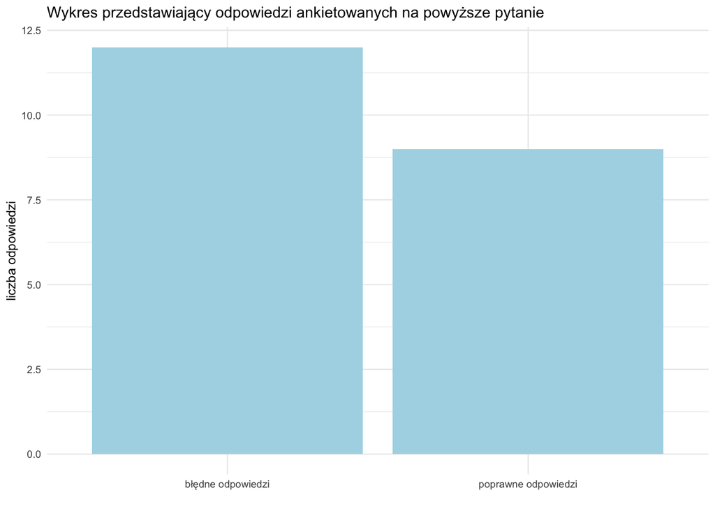

### Wykres 2

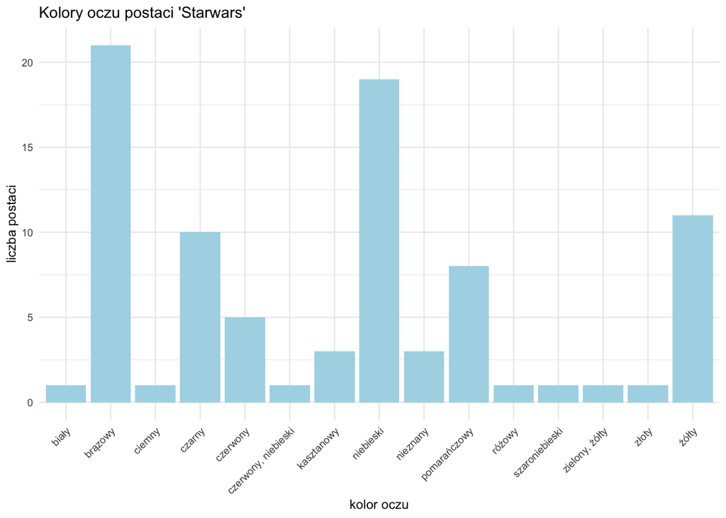

Pytanie sprawdzające umiejętność odczytania danych z powyższego wykresu brzmiało następująco:

“Ile postaci z”Gwiezdnych Wojen” ma oczy koloru czarnego?“, do wyboru były trzy odpowiedzi:

1. 10
2. 8
3. 12

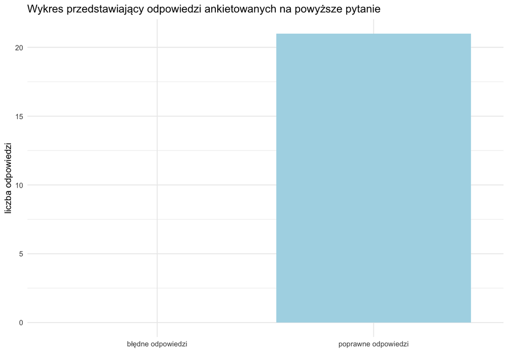

### Wykres 3

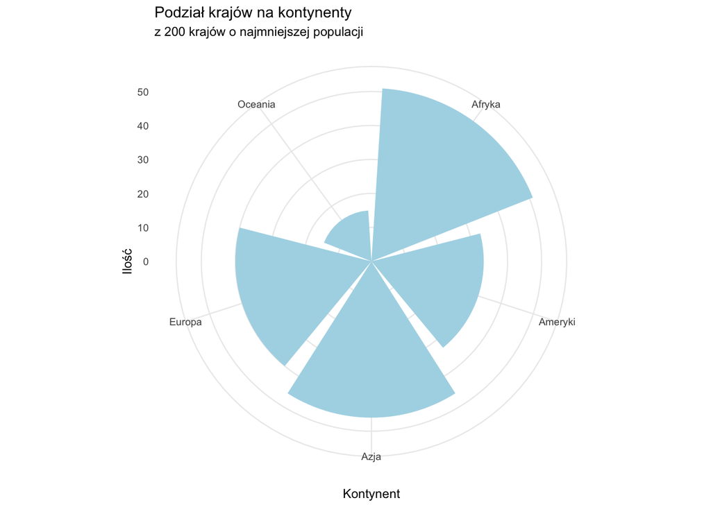

Pytanie sprawdzające umiejętność odczytania danych z powyższego wykresu brzmiało następująco:

“Ile krajów leży w Azji, spośród 200 krajów o najmniejszej populacji?”, natomiast do wyboru były trzy odpowiedzi:

1. 42
2. 44
3. 46

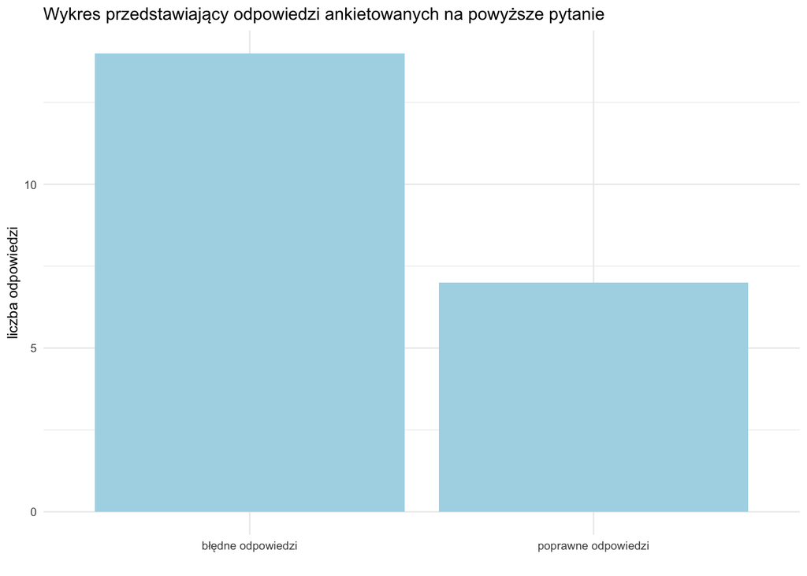

### Wykres 4

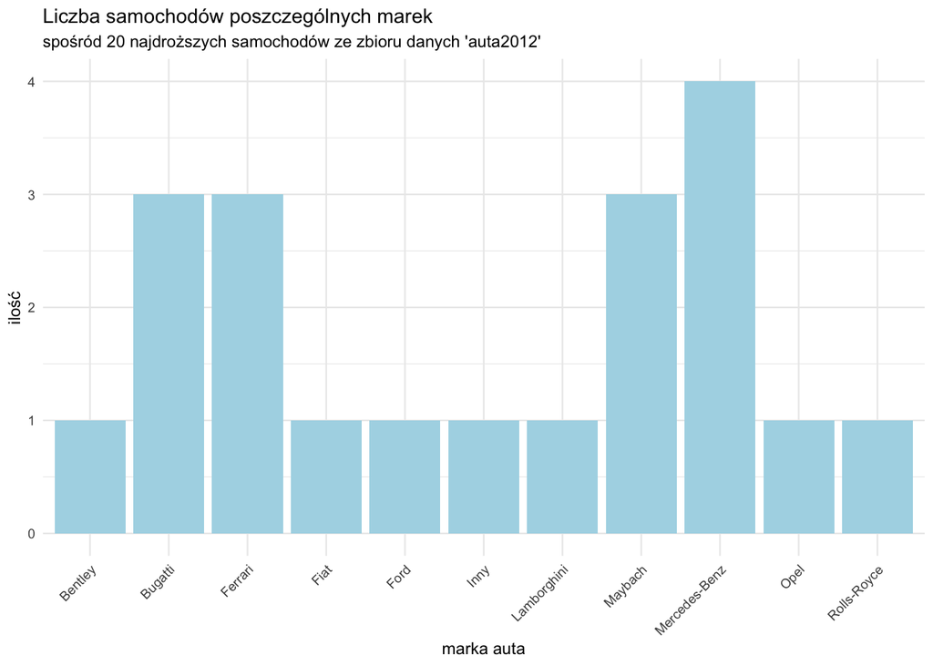

Pytanie sprawdzające umiejętność odczytania danych z powyższego wykresu brzmiało następująco:

“Ile samochodów marki fiat znalazło się pośród 20 najdroższych z tego zbioru?”, natomiast do wyboru były trzy odpowiedzi:

1. 1
2. 2
3. 3

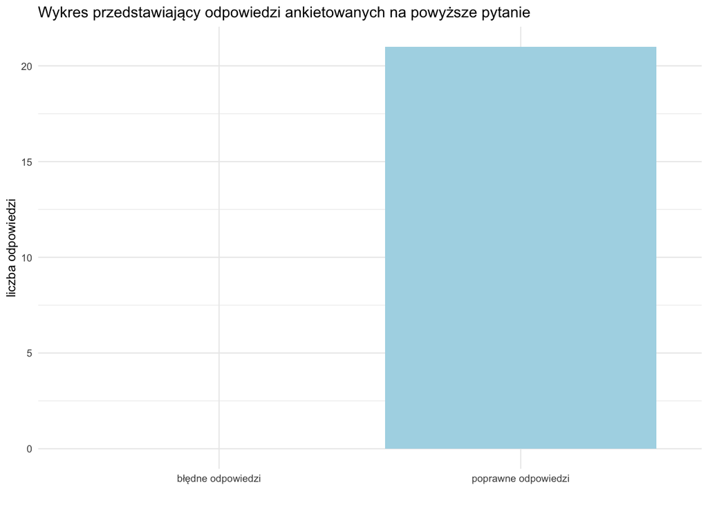

## 4. PODSUMOWANIE

Przeprowadzony eksperyment potwierdza postawioną przeze mnie powyżej tezę, że dane są łatwiejsze do odczytania z wykresów o współrzędnych kartezjańskich, niż o współrzędnych biegunowych.